# Analysing USA NOAA storm dataset for predictions

sahil jagdale

August 21, 2016

# Introduction:

The given report is about the analysis done on the dataset of U.S. National Oceanic and Atmospheric Administration’s(NOAA) storm dataset.This database tracks the major storm and weather conditions and events occured in United States and tells about the estimated fatalities,injuries and property damage as well as the crop damage as per economic perspective.We will examine the extreem events occured in terms of public health and economic perspective.

# Synopsis:

Before loading the data we have to load some libraries.

```r
# Load required libraries.  Set Warning=False and Message=False to hide the
# verbose messages printed while importing libraries
library("ggplot2")
library("grid")
library("utils")
library("plyr")
```

# Data Processing:

## i) Loading the dataset:

```r
 data_filename <- "repdata_data_StormData.csv.bz2"

  if (!file.exists(data_filename)){
    fileURL <- "https://d396qusza40orc.cloudfront.net/repdata%2Fdata%2FStormData.csv.bz2"
    download.file(fileURL, data_filename)
  }

  if (!exists('stormData')) {
  stormData <- read.csv("repdata_data_StormData.csv.bz2", stringsAsFactors = FALSE)
  }
```

summarized data is as follows.

```r
  summary(stormData)
```

```
##     STATE__       BGN_DATE           BGN_TIME          TIME_ZONE
##  Min.   : 1.0   Length:902297      Length:902297      Length:902297
##  1st Qu.:19.0   Class :character   Class :character   Class :character
##  Median :30.0   Mode  :character   Mode  :character   Mode  :character
##  Mean   :31.2
##  3rd Qu.:45.0
##  Max.   :95.0
##
##      COUNTY       COUNTYNAME           STATE              EVTYPE
##  Min.   :  0.0   Length:902297      Length:902297      Length:902297
##  1st Qu.: 31.0   Class :character   Class :character   Class :character
##  Median : 75.0   Mode  :character   Mode  :character   Mode  :character
##  Mean   :100.6
##  3rd Qu.:131.0
##  Max.   :873.0
##
##    BGN_RANGE          BGN_AZI           BGN_LOCATI
##  Min.   :   0.000   Length:902297      Length:902297
##  1st Qu.:   0.000   Class :character   Class :character
##  Median :   0.000   Mode  :character   Mode  :character
##  Mean   :   1.484
##  3rd Qu.:   1.000
##  Max.   :3749.000
##
##    END_DATE           END_TIME           COUNTY_END COUNTYENDN
##  Length:902297      Length:902297      Min.   :0    Mode:logical
##  Class :character   Class :character   1st Qu.:0    NA's:902297
##  Mode  :character   Mode  :character   Median :0
##                                        Mean   :0
##                                        3rd Qu.:0
##                                        Max.   :0
##
##    END_RANGE          END_AZI           END_LOCATI
##  Min.   :  0.0000   Length:902297      Length:902297
##  1st Qu.:  0.0000   Class :character   Class :character
##  Median :  0.0000   Mode  :character   Mode  :character
##  Mean   :  0.9862
##  3rd Qu.:  0.0000
##  Max.   :925.0000
##
```

[output cut: 33 more lines]

```
##  Min.   :-14451   Min.   :   0   Min.   :-14455   Length:902297
##  1st Qu.:  7247   1st Qu.:   0   1st Qu.:     0   Class :character
##  Median :  8707   Median :   0   Median :     0   Mode  :character
##  Mean   :  6940   Mean   :1452   Mean   :  3509
##  3rd Qu.:  9605   3rd Qu.:3549   3rd Qu.:  8735
##  Max.   : 17124   Max.   :9706   Max.   :106220
##                   NA's   :40
##      REFNUM
##  Min.   :     1
##  1st Qu.:225575
##  Median :451149
##  Mean   :451149
##  3rd Qu.:676723
##  Max.   :902297
##
```

## ii) Trimming the dataset:

```
we have to trim the datasets for our questions to be precisely answered.
```

```r
# Trim the data set to required columns only
stormEvent <- stormData[, c("BGN_DATE", "EVTYPE", "FATALITIES", "INJURIES",
                            "PROPDMG", "PROPDMGEXP", "CROPDMG", "CROPDMGEXP")]

# Create subset for Question 1 and Question 2

# Select data for Fatalities and injuries for Question 1
eventHealth <- subset(stormEvent, !stormEvent$FATALITIES == 0 & !stormEvent$INJURIES ==
                        0, select = c(EVTYPE, FATALITIES, INJURIES))

# Select data for Property Damage and Crop Damage for Question 2
eventEconomic <- subset(stormEvent, !stormEvent$PROPDMG == 0 & !stormEvent$CROPDMG ==
                          0, select = c(EVTYPE, PROPDMG, PROPDMGEXP, CROPDMG, CROPDMGEXP))
```

# Question 1.Across the United States, which types of events (as indicated in the EVTYPE variable) are most harmful with respect to population health?

the following code chunk will produce the event which are hazardous to population health.

```r
# Create separate data set for Injury and Fatalities Fatalities
eventHealth_Death <- aggregate(eventHealth$FATALITIES, by = list(eventHealth$EVTYPE),
                               FUN = sum)
# Give proper name for columns
colnames(eventHealth_Death) <- c("EVENTTYPE", "FATALITIES")

# Injury
eventHealth_Inj <- aggregate(eventHealth$INJURIES, by = list(eventHealth$EVTYPE),
                             FUN = sum)
# Give column name
colnames(eventHealth_Inj) <- c("EVENTTYPE", "INJURIES")

# Let's reorder 2 dataset and filter top 5 events for both dataset
eventHealth_Death <- eventHealth_Death[order(eventHealth_Death$FATALITIES, decreasing = TRUE),
                                       ][1:5, ]

eventHealth_Inj <- eventHealth_Inj[order(eventHealth_Inj$INJURIES, decreasing = TRUE),
                                   ][1:5, ]
```

now we will create a plot on basis of these top 5 fatalities and injuries.

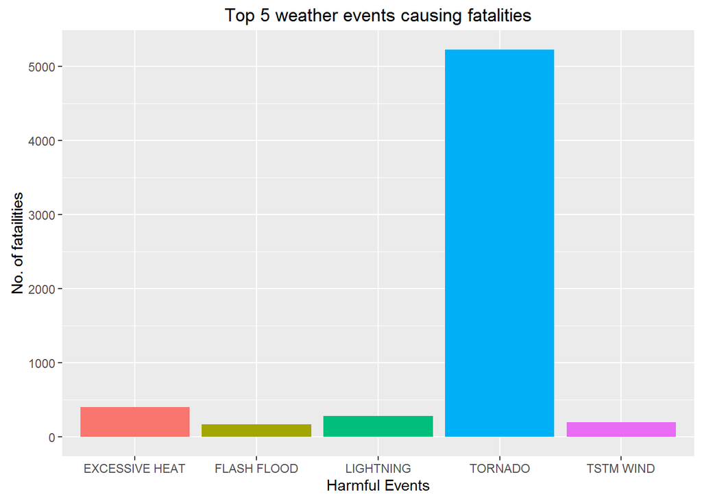

```r
  # plot top 5 events for fatalities and injuries

# Plot Fatalities and store at Death_plot
Death_plot <- ggplot() + geom_bar(data = eventHealth_Death,
                                  aes(x = EVENTTYPE, y = FATALITIES,
                                      fill = interaction(FATALITIES, EVENTTYPE)),
                                  stat = "identity",
                                  show.legend = F) +
                                  xlab("Harmful Events") +
                                  ylab("No. of fatailities") +
                                  ggtitle("Top 5 weather events causing fatalities")

# Plot injuries and store at variable Inj_plot
Inj_plot <- ggplot() + geom_bar(data = eventHealth_Inj,
                                  aes(x = EVENTTYPE, y = INJURIES,
                                      fill = interaction(INJURIES, EVENTTYPE)),
                                  stat = "identity",
                                  show.legend = F) +
                                  xlab("Harmful Events") +
                                  ylab("No. of injuries") +
                                  ggtitle("Top 5 weather events causing injuries")

Death_plot
```

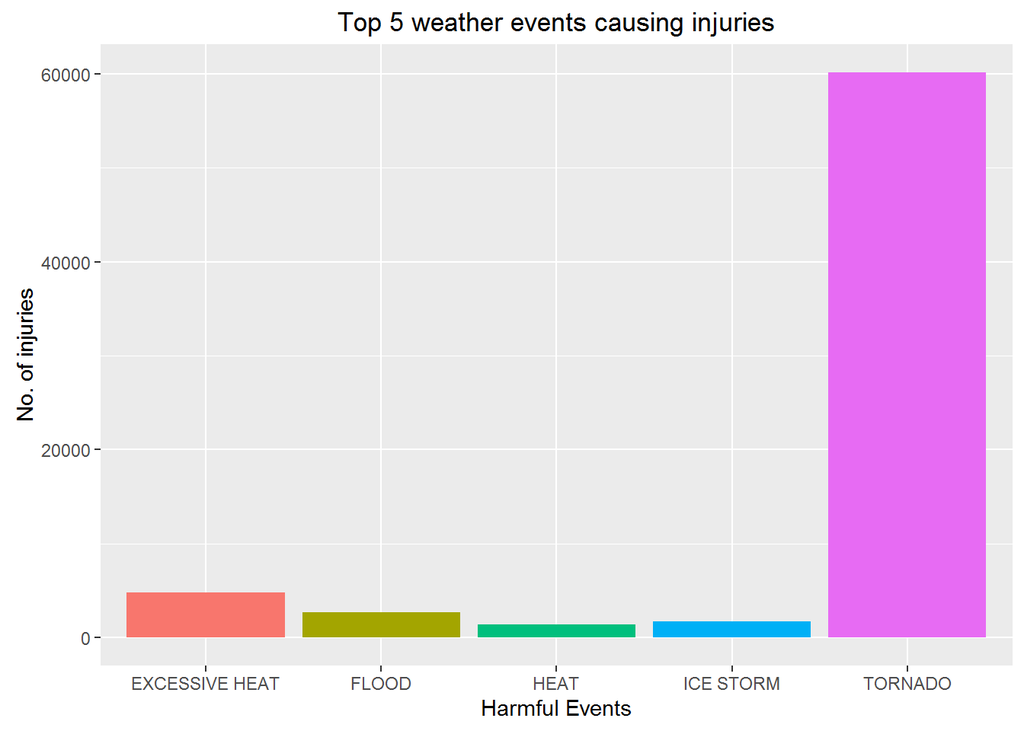

```r
Inj_plot
```

### From the plots shown above we can see tha tornado is the main cause for population health.

According to the documentation (page 12), the PROPDMG and CROPDMG variables are encoded by PROPDMGEXP and CROPDMGEXP variables, respectively. They represent magnitude values, including “H” for hundreds, “K” for thousands, “M”" for millions and “B” for billions. In order to decode PROPDMG and CROPDMG, I created new numeric variables.

```r
  stormData$PROPMULT <- 1
  stormData$PROPMULT[stormData$PROPDMGEXP =="H"] <- 100
  stormData$PROPMULT[stormData$PROPDMGEXP =="K"] <- 1000
  stormData$PROPMULT[stormData$PROPDMGEXP =="M"] <- 1000000
  stormData$PROPMULT[stormData$PROPDMGEXP =="B"] <- 1000000000

  stormData$CROPMULT <- 1
  stormData$CROPMULT[stormData$CROPDMGEXP =="H"] <- 100
  stormData$CROPMULT[stormData$CROPDMGEXP =="K"] <- 1000
  stormData$CROPMULT[stormData$CROPDMGEXP =="M"] <- 1000000
  stormData$CROPMULT[stormData$CROPDMGEXP =="B"] <- 1000000000
```

# Question 2. Across the United States, which types of events have the greatest economic consequences?

### Result

```r
aggregate_data <- ddply(.data = stormData, .variables = .(EVTYPE), property_damage = sum(PROPDMG * PROPMULT), crop_damage = sum(CROPDMG * CROPMULT), summarize)

damage_data <- arrange(aggregate_data, desc(property_damage + crop_damage))
```

lets plot the graph to see which event cause the most economic impact

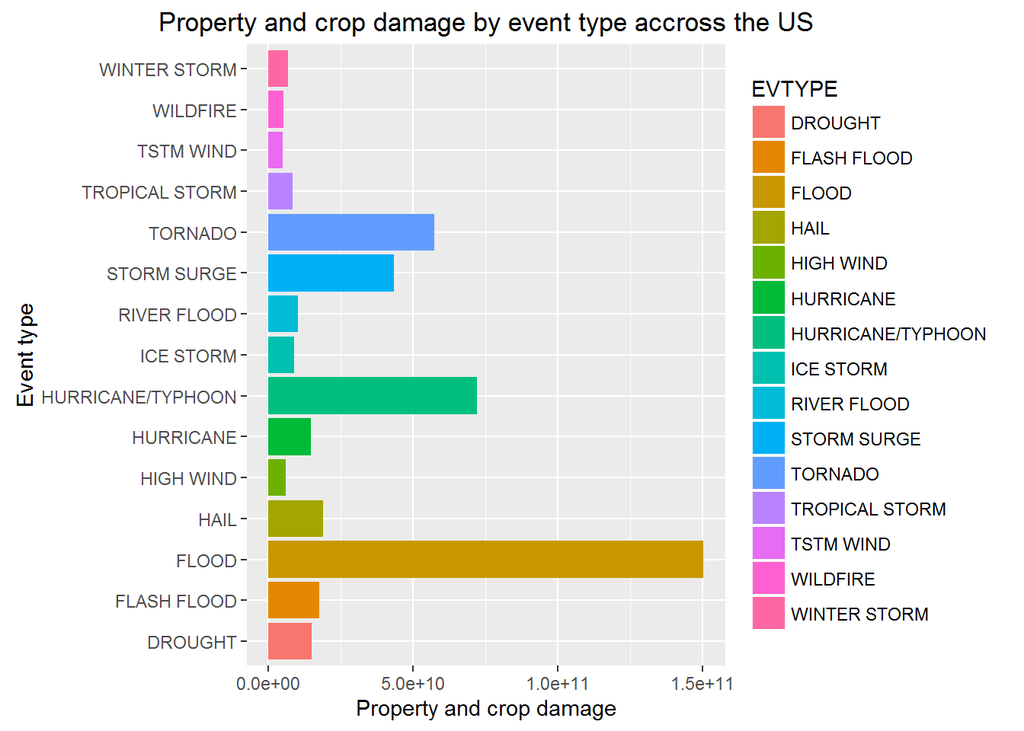

```r
 ggplot(data = head(damage_data, 15), aes(x = factor(EVTYPE), y = (property_damage + crop_damage), fill = EVTYPE)) + geom_bar(stat="identity") + coord_flip() + labs(y = "Property and crop damage", x = "Event type", title = "Property and crop damage by event type accross the US")
```

#Summary:

From these data and grpahs, we found that Tornado are most harmful with respect to population health, while Flood have the greatest economic consequences.